# 02: Manipulating Time Series Data

Herman Yu

# Introduction

Studying and modeling time series data will require us to manipulate time series data using computer code. We can choose to manually handle time-series objects as traditional arrays, but then we would need to meticulously curate the metadata attached to the object. Life would be much easier if we use one of the many libraries in R to handle our time series data for us. The `tsibble` and `feasts` libraries allow us to store data as time series objects and extract useful features for analysis.

# 2.1 `tsibble` Objects

A **time-series** is a sequence of real-values, indexed by some notion of time. A time-series can be represented by a `tsibble` object, which is defined by the time index and the sequence of values.

```r
options(scipen=999)
library(tsibble)
library(dplyr)
library(lubridate)

time <- c("2024-01-01", "2024-02-01", "2024-03-01", "2024-04-01",
          "2024-05-01", "2024-06-01", "2024-07-01", "2024-08-01")

sales <- c(123, 234, 158, 145,
           288, 198, 193, 62)

revenue <- c(100502, 230404, 151001, 134104,
             300034, 201008, 198882, 75804)


data <- tsibble(
  month = yearmonth(time), # create a month column to use as index
  sales = sales, # the value of the time-series
  revenue = revenue, # the value of another time-series
  index = month, # we can directly declare that 'month' should be the index
)

data
```

```
## # A tsibble: 8 x 3 [1M]
##      month sales revenue
##      <mth> <dbl>   <dbl>
## 1 2024 Jan   123  100502
## 2 2024 Feb   234  230404
## 3 2024 Mar   158  151001
## 4 2024 Apr   145  134104
## 5 2024 May   288  300034
## 6 2024 Jun   198  201008
## 7 2024 Jul   193  198882
## 8 2024 Aug    62   75804
```

Notice the header says `8 x 3 [1M]` indicating that `tsibble` was able to infer the structure of the time-series data: 8 rows x 3 columns, with time-steps of 1-month. This highlights the main point of using `tsibble` objects: they store all the relevant metadata associated with time-series. This makes it easy to apply time-specific manipulations that would normally be very tedious for a normal `tibble` object.

`tsibble` objects behave like regular `tibble` objects, which means we can manipulate their data using `dplyr` verbs:

```r
# create indicator variable for high revenue
data %>%
  mutate(
    is_revenue_more_than_200 = ifelse(revenue > 200000, 1, 0)
  )
```

```
## # A tsibble: 8 x 4 [1M]
##      month sales revenue is_revenue_more_than_200
##      <mth> <dbl>   <dbl>                    <dbl>
## 1 2024 Jan   123  100502                        0
## 2 2024 Feb   234  230404                        1
## 3 2024 Mar   158  151001                        0
## 4 2024 Apr   145  134104                        0
## 5 2024 May   288  300034                        1
## 6 2024 Jun   198  201008                        1
## 7 2024 Jul   193  198882                        0
## 8 2024 Aug    62   75804                        0
```

```r
# filter to rows with high sales
data %>%
  select(sales) %>%
  filter(
    sales > 150
  )
```

```
## # A tsibble: 5 x 2 [1M]
##   sales    month
##   <dbl>    <mth>
## 1   234 2024 Feb
## 2   158 2024 Mar
## 3   288 2024 May
## 4   198 2024 Jun
## 5   193 2024 Jul
```

Finally, a regular `tibble` object can be converted into a `tsibble` object using the `as_tsibble()` function:

```r
time <- c("2024-01-01", "2024-02-01", "2024-03-01", "2024-04-01",
          "2024-05-01", "2024-06-01", "2024-07-01", "2024-08-01")

sales <- c(123, 234, 158, 145,
           288, 198, 193, 62)

revenue <- c(100502, 230404, 151001, 134104,
             300034, 201008, 198882, 75804)

# store our data in a tibble object
data_tibble <- tibble(
  date = time,
  sales = sales,
  revenue = revenue
)

data_tibble
```

```
## # A tibble: 8 × 3
##   date       sales revenue
##   <chr>      <dbl>   <dbl>
## 1 2024-01-01   123  100502
## 2 2024-02-01   234  230404
## 3 2024-03-01   158  151001
## 4 2024-04-01   145  134104
## 5 2024-05-01   288  300034
## 6 2024-06-01   198  201008
## 7 2024-07-01   193  198882
## 8 2024-08-01    62   75804
```

```r
# convert our tibble object into a tsibble object
data <- data_tibble %>%
  mutate(
    month = yearmonth(date) # coerce the char column 'date' into month-type
  ) %>%
  select(
    -date # don't need this column anymore
  ) %>%
  select(
    month, # rearrange columns for readability
    everything()
  ) %>%
  as_tsibble(
    index = month # which column is the time-index?
  )

data
```

```
## # A tsibble: 8 x 3 [1M]
##      month sales revenue
##      <mth> <dbl>   <dbl>
## 1 2024 Jan   123  100502
## 2 2024 Feb   234  230404
## 3 2024 Mar   158  151001
## 4 2024 Apr   145  134104
## 5 2024 May   288  300034
## 6 2024 Jun   198  201008
## 7 2024 Jul   193  198882
## 8 2024 Aug    62   75804
```

# Time-Series Plots

A **time-series plot** is a graph of a time-series’ values across time. We can do this directly by using the `ggplot2` package:

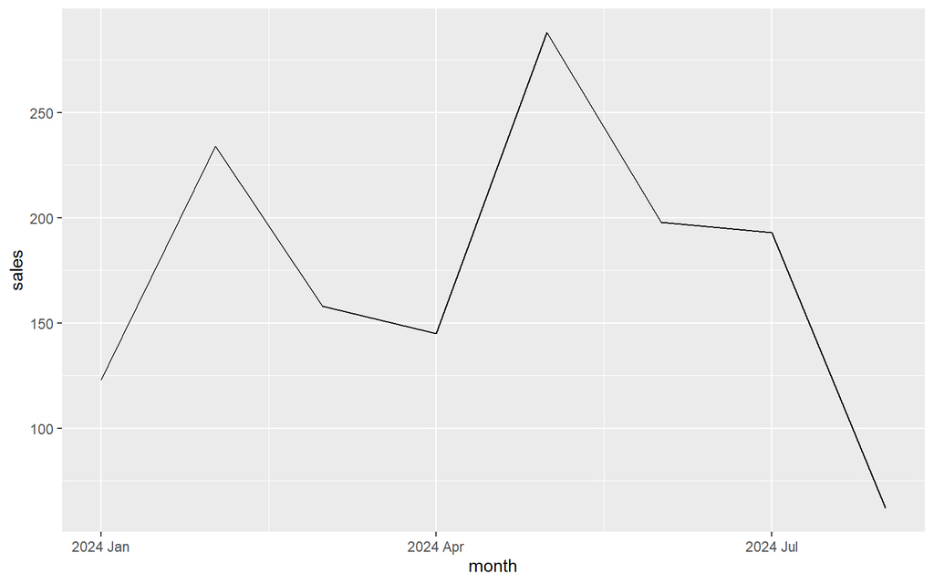

```r
library(ggplot2)
data %>%
  ggplot(aes(x = month, y = sales)) +
  geom_line()
```

However, notice that we have to specify the `month` as the x-axis. Since a `tsibble` object knows which column is the time-index, it would be great if our `tsibble` object could pass this metadata along to a plotting function and automatically set the x-axis as `month`. Thankfully, time-series packages like `feasts` and `fabletools` both come with an `autoplot` function that does just this

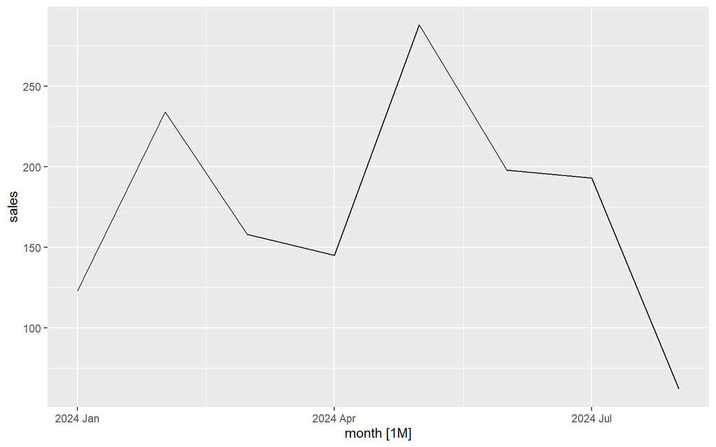

```r
# time series plot of the sales column
# using the autoplot() function found in feasts
data %>%
  feasts::autoplot(sales)
```

The `autoplot` function returns a `ggplot` object, which means we can manipulate the graphic like a normal `ggplot`:

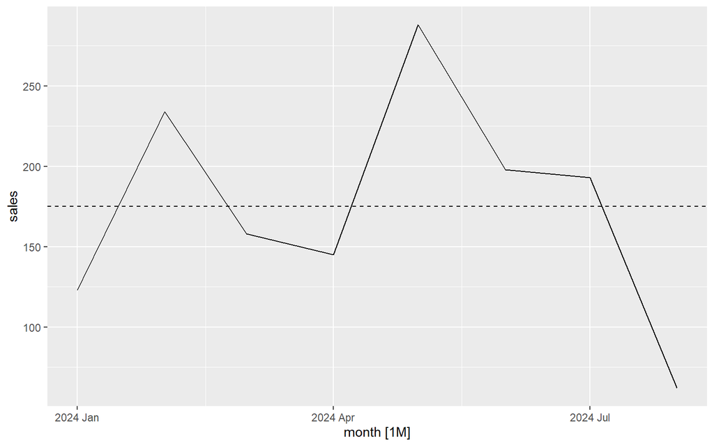

```r
# add a horizontal line indicating the sample mean
# by using normal ggplot syntax
data %>%
  feasts::autoplot(sales) +
  geom_hline(yintercept = mean(data$sales), linetype = "dashed")
```

# The `fpp3` Package

We will need to load actual time-series data sets to study, as well as various different libraries for manipulating time-series data like `tsibble`, `dplyr`, `feasts`, etc. This can all be done with a single library called `fpp3` which is a companion package to the textbook [Forecasting: Principals and Practices (3rd Edition)](https://otexts.com/fpp3/index.html):

```r
library(fpp3)

# fpp3 will automatically load time-series data sets as tsibble objects
# for example: the 'PBS' data set contains monthly Australian Medicare
# prescription data
PBS %>%
  head()
```

```
## # A tsibble: 6 x 9 [1M]
## # Key:       Concession, Type, ATC1, ATC2 [1]
##      Month Concession   Type        ATC1  ATC1_desc                       ATC2  ATC2_desc                   Scripts  Cost
##      <mth> <chr>        <chr>       <chr> <chr>                           <chr> <chr>                         <dbl> <dbl>
## 1 1991 Jul Concessional Co-payments A     Alimentary tract and metabolism A01   STOMATOLOGICAL PREPARATIONS   18228 67877
## 2 1991 Aug Concessional Co-payments A     Alimentary tract and metabolism A01   STOMATOLOGICAL PREPARATIONS   15327 57011
## 3 1991 Sep Concessional Co-payments A     Alimentary tract and metabolism A01   STOMATOLOGICAL PREPARATIONS   14775 55020
## 4 1991 Oct Concessional Co-payments A     Alimentary tract and metabolism A01   STOMATOLOGICAL PREPARATIONS   15380 57222
## 5 1991 Nov Concessional Co-payments A     Alimentary tract and metabolism A01   STOMATOLOGICAL PREPARATIONS   14371 52120
## 6 1991 Dec Concessional Co-payments A     Alimentary tract and metabolism A01   STOMATOLOGICAL PREPARATIONS   15028 54299
```

Various libraries like `tsibble`, `dplyr`, `feasts`, etc. will also be loaded by the `fpp3` library, allow us to start manipulating the time series data sets right away:

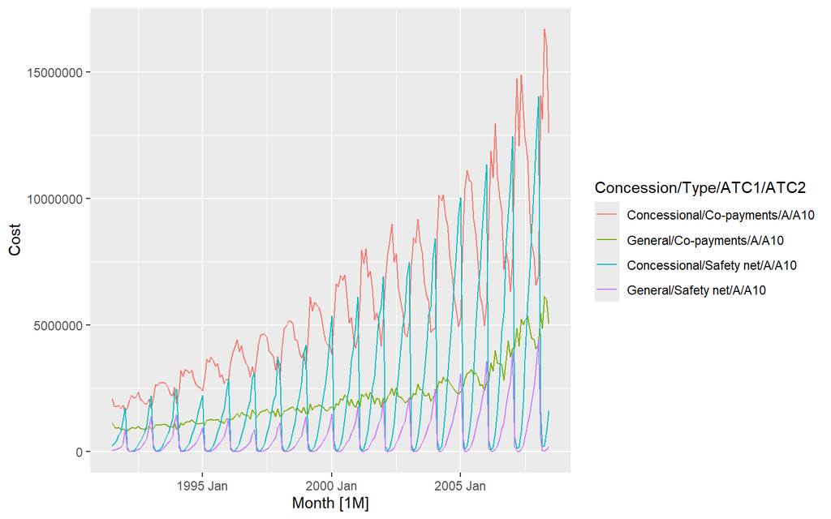

```r
PBS %>%
  filter(ATC2 == "A10") %>%
  autoplot(Cost)
```

Notice that the data automatically gets grouped by the various combinations of `Concession`, `Type`, `ATC1`, and `ATC2` values. These columns are examples of **key columns** which represent specific dimensions the data can be aggregated or sliced by.

Since `tsibble` objects represent time-series data sets, any operations on `tsibble` objects *must return* a time-series. In particular, this means that any aggregation operations must group by the time-index to ensure the result is also a time series:

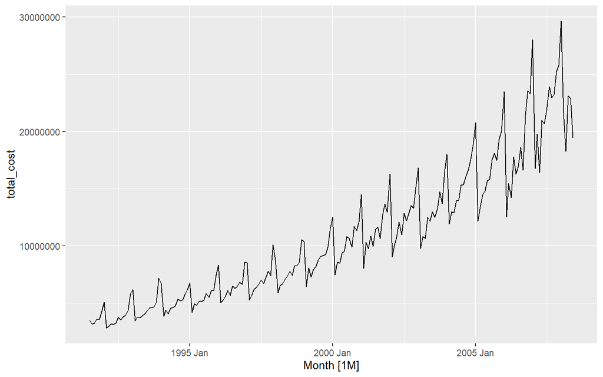

```r
PBS %>%
  filter(ATC2 == "A10") %>%
  summarise(
    total_cost = sum(Cost)
  ) %>%
  autoplot(total_cost)
```